# 1 ImageNet, ILSVRC, and Milestone Architectures

The ILSVRC is an annual computer vision competition developed upon a subset of a publicly available computer vision dataset called ImageNet. As such, the tasks and even the challenge itself is often referred to as the ImageNet Competition.

## 1.1 ImageNet Dataset

ImageNet is a large **dataset** of annotated photographs intended for computer vision research.

## 1.2 ImageNet Large Scale Visual Recognition Challenge (ILSVRC)

The ImageNet Large Scale Visual Recognition Challenge, or ILSVRC for short, is an annual computer vision competition held in which challenge tasks use subsets of the ImageNet dataset.

The annual challenge focuses on multiple tasks for **image classification** that includes both assigning a class label to an image based on the main object in the photograph and **object detection** that involves localizing objects within the photograph.

The general challenge tasks for most years are as follows:

> **Image classification**: Predict the classes of objects present in an image.

> **Single-object localization**: Image classification + draw a bounding box around one example of each object present.

> **Object detection**: Image classification + draw a bounding box around each object present.

## 1.3 Deep Learning Milestones From ILSVRC

### 1.3.1 ILSVRC-2012

#### AlexNet (SuperVision)

Alex Krizhevsky, et al. from the University of Toronto in their 2012 paper titled ImageNet Classification with Deep Convolutional Neural Networks developed a convolutional neural network that achieved top results on the ILSVRC-2010 and ILSVRC-2012 image classification tasks. These results sparked interest in deep learning in computer vision.

### 1.3.2 ILSVRC-2013

#### ZFNet (Clarifai)

Matthew Zeiler and Rob Fergus proposed a variation of AlexNet generally referred to as ZFNet in their 2013 paper titled Visualizing and Understanding Convolutional Networks, a variation of which won the ILSVRC-2013 image classification task.

### 1.3.3 ILSVRC-2014

#### Inception (GoogLeNet)

Christian Szegedy, et al. from Google achieved top results for object detection with their GoogLeNet model that made use of the inception module and architecture. This approach was described in their 2014 paper titled Going Deeper with Convolutions.

#### VGG

Karen Simonyan and Andrew Zisserman from the Oxford Vision Geometry Group (VGG) achieved top results for image classification and localization with their VGG model. Their approach is described in their 2015 paper titled Very Deep Convolutional Networks for Large- Scale Image Recognition.

### 1.3.4 ILSVRC-2015

#### ResNet (MSRA)

Kaiming He, et al. from Microsoft Research achieved top results for object detection and object detection with localization tasks with their Residual Network or ResNet described in their 2015 paper titled Deep Residual Learning for Image Recognition.

# 2 How Milestone Model Architectural Innovations Work

## 2.1 Architectural Design for CNNs

The elements of a convolutional neural network, such as convolutional and pooling layers, are relatively straightforward to understand. The challenging part of using convolutional neural networks in practice is how to design model architectures that best use these simple elements.

We will begin with LeNet-5 that is often described as the first successful and important application of CNNs prior to the ILSVRC, then look at four different winning architectural innovations for CNNs developed for the ILSVRC, namely, AlexNet, VGG, Inception, and ResNet.

## 2.2 LeNet-5

Perhaps the first widely known and successful application of convolutional neural networks was LeNet-5, described by Yann LeCun, et al. in their 1998 paper titled Gradient-Based Learning Applied to Document Recognition.

The system was developed for use in a handwritten character recognition problem and demonstrated on the MNIST standard dataset, achieving approximately 99.2% classification accuracy (or a 0.8% error rate).

The model proposes a pattern of a convolutional layer followed by an average pooling layer, referred to as a subsampling layer. This pattern is repeated two and a half times before the output feature maps are flattened and fed to a number of fully connected layers for interpretation and a final prediction.

[figure not shown]

We can summarize the key aspects of the architecture relevant in modern models as follows:

> - Fixed-sized input images.
> - Group convolutional and pooling layers into blocks.
> - Repetition of convolutional-pooling blocks in the architecture.
> - Increase in the number of filters with the depth of the network.
> - Distinct feature extraction and classifier parts of the architecture.

## 2.3 AlexNet

More broadly, the paper showed that it is possible to develop deep and effective end-to-end models for a challenging problem without using unsupervised pre-training techniques that were popular at the time.

AlexNet made use of the rectified linear activation function, or ReLU, as the nonlinearly after each convolutional layer, instead of S-shaped functions such as the logistic or Tanh that were common up until that point.

Also, a softmax activation function was used in the output layer, now a staple for multiclass classification with neural networks.

The average pooling used in LeNet-5 was replaced with a max pooling method, although in this case, overlapping pooling was found to outperform non-overlapping pooling that is commonly used today (e.g. stride of pooling operation is the same size as the pooling operation, e.g. 2 by 2 pixels).

To address overfitting, the newly proposed **dropout** method was used between the fully connected layers of the classifier part of the model to improve generalization error.

We can summarize the key aspects of the architecture relevant in modern models as follows:

> - Use of the ReLU activation function after convolutional layers and softmax for the output layer.
> - Use of Max Pooling instead of Average Pooling.
> - Use of Dropout regularization between the fully connected layers.
> - Pattern of a convolutional layer fed directly to another convolutional layer.
> - Use of Data Augmentation.

## 2.4 VGG

A number of variants of the architecture were developed and evaluated, although two are referred to most commonly given their performance and depth. They are named for the number of layers: they are the VGG-16 and the VGG-19 for 16 and 19 learned layers respectively.

This, in turn, has led to the heavy use of pre-trained models like VGG in transfer learning as a starting point on new computer vision tasks. We can summarize the key aspects of the architecture relevant in modern models as follows:

> - Use of very small convolutional filters, e.g. 3 × 3 and 1 × 1 with a stride of one.
> - Use of max pooling with a size of 2 × 2 and a stride of the same dimensions.
> - The importance of stacking convolutional layers together before using a pooling layer to define a block.
> - Dramatic repetition of the convolutional-pooling block pattern.
> - Development of very deep (16 and 19 layer) models.

## 2.5 Inception and GoogLeNet

The key innovation on the inception models is called the **inception module**. This is a block of parallel convolutional layers with different sized filters (e.g. 1 × 1, 3 × 3, 5 × 5) and a 3 × 3 max pooling layer, the results of which are then concatenated.

We can summarize the key aspects of the architecture relevant in modern models as follows:

> - Development and repetition of the Inception module.
> - Heavy use of the 1 × 1 convolution to reduce the number of channels.
> - Use of error feedback at multiple points in the network.
> - Development of very deep (22-layer) models.
> - Use of global average pooling for the output of the model.

## 2.6 Residual Network or ResNet

Key to the model design is the idea of **residual blocks** that make use of shortcut connections.

A residual block is a pattern of two convolutional layers with ReLU activation where the output of the block is combined with the input to the block, e.g. the shortcut connection.

We can summarize the key aspects of the architecture relevant in modern models as follows:

> - Use of shortcut connections.
> - Development and repetition of the residual blocks.
> - Development of very deep (152-layer) models.

# 3 How to Use 1x1 Convolutions to Manage Model Complexity

A problem with deep convolutional neural networks is that the number of feature maps often increases with the depth of the network. This problem can result in a dramatic increase in the number of parameters and computation required when larger filter sizes are used, such as 5 × 5 and 7 × 7.

To address this problem, a 1 × 1 convolutional layer can be used that offers a channel-wise pooling, often called feature map pooling or a projection layer. This simple technique can be used for dimensionality reduction, decreasing the number of feature maps whilst retaining their salient features.

## 3.1 Convolutions Over Channels

A filter must have the same depth or number of channels as the input, yet, regardless of the depth of the input and the filter, the resulting output is a single number and one filter creates a feature map with a single channel.

> If the input is a block of feature maps from another convolutional or pooling layer and has the depth of 64, then the 3×3 filter will be applied in 3×3×64 blocks to create the single values to make up the single output feature map.

The depth of the output of one convolutional layer is only defined by the number of parallel filters applied to the input.

## 3.2 Problem of Too Many Feature Maps

A large number of feature maps in a convolutional neural network can cause a problem as a convolutional operation must be performed down through the depth of the input. This is a particular problem if the convolutional operation being performed is relatively large, such as 5 × 5 or 7 × 7 pixels, as it can result in considerably more parameters (weights) and, in turn, computation to perform the convolutional operations (large space and time complexity).

Pooling layers are designed to downscale feature maps and systematically halve the width and height of feature maps in the network. Nevertheless, pooling layers do not change the number of filters in the model, the depth, or number of channels.

Deep convolutional neural networks require a corresponding pooling type of layer that can downsample or reduce the depth or number of feature maps.

## 3.3 Downsample Feature Maps With 1x1 Filters

The solution is to use a 1 × 1 filter to downsample the depth or number of feature maps.

The 1 × 1 filter is so simple that it does not involve any neighboring pixels in the input; it may not be considered a convolutional operation. Instead, it is a linear weighting or projection of the input.

A convolutional layer with a 1×1 filter can, therefore, be used at any point in a convolutional neural network to control the number of feature maps. As such, it is often referred to as a projection operation or projection layer, or even a feature map or channel pooling layer.

## 3.4 Examples of How to Use 1x1 Convolutions

Consider that we have a convolutional neural network that expected color images input with the square shape of 256 × 256 × 3 pixels. These images then pass through a first hidden layer with 512 filters, each with the size of 3 × 3 with the same padding, followed by a ReLU activation function. The example below demonstrates this simple model.

```python
# example of simple cnn model
from tensorflow.keras.models import Sequential
from tensorflow.keras.layers import Conv2D
# create model
model = Sequential()
model.add(Conv2D(512, (3,3), padding='same', activation='relu', input_shape=(256, 256, 3)))
# summarize model
model.summary()
```

```
Model: "sequential"
_________________________________________________________________
Layer (type)                 Output Shape              Param #
=================================================================
conv2d (Conv2D)              (None, 256, 256, 512)     14336
=================================================================
Total params: 14,336
Trainable params: 14,336
Non-trainable params: 0
_________________________________________________________________
```

```python
512 * (3 * 3 * 3 + 1)
```

```
14336
```

### 3.4.1 Example of Projecting Feature Maps

1 × 1 filter can be used to create a projection of the feature maps. The number of feature maps created will be the same number and the effect may be a refinement of the features already extracted. This is often called channel-wise pooling, as opposed to traditional feature-wise pooling on each channel.

```python
# create model
model = Sequential()
model.add(Conv2D(512, (3,3), padding='same', activation='relu', input_shape=(256, 256, 3)))
model.add(Conv2D(512, (1,1), activation='relu'))
# summarize model
model.summary()
```

```
Model: "sequential_1"
_________________________________________________________________
Layer (type)                 Output Shape              Param #
=================================================================
conv2d_1 (Conv2D)            (None, 256, 256, 512)     14336
_________________________________________________________________
conv2d_2 (Conv2D)            (None, 256, 256, 512)     262656
=================================================================
Total params: 276,992
Trainable params: 276,992
Non-trainable params: 0
_________________________________________________________________
```

```python
(1 * 1 * 512 + 1) * 512
```

```
262656
```

### 3.4.2 Example of Decreasing Feature Maps

The 1 × 1 filter can be used to decrease the number of feature maps. This is the most common application of this type of filter and in this way, the layer is often called a feature map pooling layer. In this example, we can decrease the depth (or channels) from 512 to 64.

```python
# create model
model = Sequential()
model.add(Conv2D(512, (3,3), padding='same', activation='relu', input_shape=(256, 256, 3)))
model.add(Conv2D(64, (1,1), activation='relu'))
# summarize model
model.summary()
```

```
Model: "sequential_2"
_________________________________________________________________
Layer (type)                 Output Shape              Param #
=================================================================
conv2d_3 (Conv2D)            (None, 256, 256, 512)     14336
_________________________________________________________________
conv2d_4 (Conv2D)            (None, 256, 256, 64)      32832
=================================================================
Total params: 47,168
Trainable params: 47,168
Non-trainable params: 0
_________________________________________________________________
```

```python
(1 * 1 * 512 + 1) * 64
```

```
32832
```

不加1 × 1卷积层的参数：

```python
# create model
model = Sequential()
model.add(Conv2D(512, (3,3), padding='same', activation='relu', input_shape=(256, 256, 3)))
model.add(Conv2D(64, (7,7), activation='relu'))
# summarize model
model.summary()
```

```
Model: "sequential_3"
_________________________________________________________________
Layer (type)                 Output Shape              Param #
=================================================================
conv2d_5 (Conv2D)            (None, 256, 256, 512)     14336
_________________________________________________________________
conv2d_6 (Conv2D)            (None, 250, 250, 64)      1605696
=================================================================
Total params: 1,620,032
Trainable params: 1,620,032
Non-trainable params: 0
_________________________________________________________________
```

加上1 × 1卷积层的参数：

```python
# create model
model = Sequential()
model.add(Conv2D(512, (3,3), padding='same', activation='relu', input_shape=(256, 256, 3)))
model.add(Conv2D(64, (1,1), activation='relu'))
model.add(Conv2D(64, (7,7), activation='relu'))
# summarize model
model.summary()
```

```
Model: "sequential_4"
_________________________________________________________________
Layer (type)                 Output Shape              Param #
=================================================================
conv2d_7 (Conv2D)            (None, 256, 256, 512)     14336
_________________________________________________________________
conv2d_8 (Conv2D)            (None, 256, 256, 64)      32832
_________________________________________________________________
conv2d_9 (Conv2D)            (None, 250, 250, 64)      200768
=================================================================
Total params: 247,936
Trainable params: 247,936
Non-trainable params: 0
_________________________________________________________________
```

```python
(14336 + 32832 + 200768)/(14336 + 1605696)
```

```
0.15304389049105202
```

### 3.4.3 Example of Increasing Feature Maps

The 1 × 1 filter can be used to increase the number of feature maps. This is a common operation used after a pooling layer prior to applying another convolutional layer. The projection effect of the filter can be applied as many times as needed to the input, allowing the number of feature maps to be scaled up and yet have a composition that captures the salient features of the original

```python
# create model
model = Sequential()
model.add(Conv2D(512, (3,3), padding='same', activation='relu', input_shape=(256, 256, 3)))
model.add(Conv2D(1024, (1,1), activation='relu'))
# summarize model
model.summary()
```

```
Model: "sequential_5"
_________________________________________________________________
Layer (type)                 Output Shape              Param #
=================================================================
conv2d_10 (Conv2D)           (None, 256, 256, 512)     14336
_________________________________________________________________
conv2d_11 (Conv2D)           (None, 256, 256, 1024)    525312
=================================================================
Total params: 539,648
Trainable params: 539,648
Non-trainable params: 0
_________________________________________________________________
```

## 3.5 Examples of 1x1 Filters in CNN Model Architectures

### 3.5.1 Network in Network

The 1 × 1 filter was perhaps first described and popularized in the 2013 paper by Min Lin, et al. in their paper titled Network In Network. In the paper, the authors propose the need for a MLP convolutional layer and the need for cross-channel pooling to promote learning across channels.

They describe a 1 × 1 convolutional layer as a specific implementation of cross-channel parametric pooling, which, in effect, is exactly what a 1 × 1 filter achieves.

### 3.5.2 Inception Architecture

An input block of feature maps is processed in parallel by different convolutional layers each with differently sized filters, where a 1 × 1 size filter is one of the layers used.

[figure not shown]

The output of the parallel layers are then stacked, channel-wise, resulting in very deep stacks of convolutional layers to be processed by subsequent inception modules.

[figure not shown]

### 3.5.3 Residual Architecture

The authors describe an architecture comprised of residual modules where the input to a module is **added (not concatenated)** to the output of the module in what is referred to as a shortcut connection.

> Because the input is added to the output of the module, the dimensionality must match in terms of width, height, and depth.

> Width and height can be maintained via padding, although a 1 × 1 filter is used to change the depth of the input as needed so that it can be added with the output of the module.

This type of connection is referred to as a projection shortcut connection.

[figure not shown]

> The three layers are 1×1, 3×3, and 1×1 convolutions, where the 1×1 layers are responsible for reducing and then increasing (restoring) dimensions, leaving the 3 × 3 layer a bottleneck with smaller input/output dimensions.

# 4 How To Implement Model Architecture Innovations

Models that have achieved state-of-the-art results for tasks like image classification use discrete architecture elements repeated multiple times, such as

- the VGG block in the VGG models,
- the inception module in the GoogLeNet, and
- the residual module in the ResNet.

## 4.1 How to implement VGG Blocks

The key innovation in this architecture was the definition and repetition of what we will refer to as VGG-blocks. These are groups of convolutional layers that use small filters (e.g. 3 × 3 pixels) followed by a max pooling layer.

A convolutional neural network with VGG-blocks is a sensible starting point when developing a new model from scratch as it is easy to understand, easy to implement, and very effective at extracting features from images.

We can generalize the specification of a VGG-block as one or more convolutional layers with the same number of filters and a filter size of 3 × 3, a stride of 1 × 1, same padding so the output size is the same as the input size for each filter, and the use of a rectified linear activation function. These layers are then followed by a max pooling layer with a size of 2 × 2 and a stride of the same dimensions.

```python
# Example of creating a CNN model with a VGG block
from tensorflow.keras.models import Model
from tensorflow.keras.layers import Input
from tensorflow.keras.layers import MaxPooling2D
from tensorflow.keras.utils import plot_model

# function for creating a vgg block
def vgg_block(layer_in, n_filters, n_conv):
	# add convolutional layers
	for _ in range(n_conv):
		layer_in = Conv2D(n_filters, (3,3), padding='same', activation='relu')(layer_in)
	# add max pooling layer
	layer_in = MaxPooling2D((2,2), strides=(2,2))(layer_in)
	return layer_in

# define model input
visible = Input(shape=(256, 256, 3))
# add vgg module
layer = vgg_block(visible, 64, 2)
# create model
model = Model(inputs=visible, outputs=layer)
# summarize model
model.summary()
```

```
Model: "model"
_________________________________________________________________
Layer (type)                 Output Shape              Param #
=================================================================
input_1 (InputLayer)         [(None, 256, 256, 3)]     0
_________________________________________________________________
conv2d_12 (Conv2D)           (None, 256, 256, 64)      1792
_________________________________________________________________
conv2d_13 (Conv2D)           (None, 256, 256, 64)      36928
_________________________________________________________________
max_pooling2d (MaxPooling2D) (None, 128, 128, 64)      0
=================================================================
Total params: 38,720
Trainable params: 38,720
Non-trainable params: 0
_________________________________________________________________
```

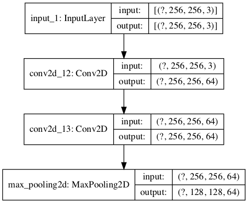

```python
# plot model architecture
plot_model(model, show_shapes=True)
```

Using VGG blocks in your own models should be common because they are so simple and effective. We can expand the example and demonstrate a single model that has three VGG blocks, the first two blocks have two convolutional layers with 64 and 128 filters respectively, the third block has four convolutional layers with 256 filters.

```python
# define model input
visible = Input(shape=(256, 256, 3))
# add vgg module
layer = vgg_block(visible, 64, 2)
# add vgg module
layer = vgg_block(layer, 128, 2)
# add vgg module
layer = vgg_block(layer, 256, 4)
# create model
model = Model(inputs=visible, outputs=layer)
# summarize model
model.summary()
```

```
Model: "model_1"
_________________________________________________________________
Layer (type)                 Output Shape              Param #
=================================================================
input_2 (InputLayer)         [(None, 256, 256, 3)]     0
_________________________________________________________________
conv2d_14 (Conv2D)           (None, 256, 256, 64)      1792
_________________________________________________________________
conv2d_15 (Conv2D)           (None, 256, 256, 64)      36928
_________________________________________________________________
max_pooling2d_1 (MaxPooling2 (None, 128, 128, 64)      0
_________________________________________________________________
conv2d_16 (Conv2D)           (None, 128, 128, 128)     73856
_________________________________________________________________
conv2d_17 (Conv2D)           (None, 128, 128, 128)     147584
_________________________________________________________________
max_pooling2d_2 (MaxPooling2 (None, 64, 64, 128)       0
_________________________________________________________________
conv2d_18 (Conv2D)           (None, 64, 64, 256)       295168
_________________________________________________________________
conv2d_19 (Conv2D)           (None, 64, 64, 256)       590080
_________________________________________________________________
conv2d_20 (Conv2D)           (None, 64, 64, 256)       590080
_________________________________________________________________
conv2d_21 (Conv2D)           (None, 64, 64, 256)       590080
_________________________________________________________________
max_pooling2d_3 (MaxPooling2 (None, 32, 32, 256)       0
=================================================================
Total params: 2,325,568
Trainable params: 2,325,568
Non-trainable params: 0
_________________________________________________________________
```

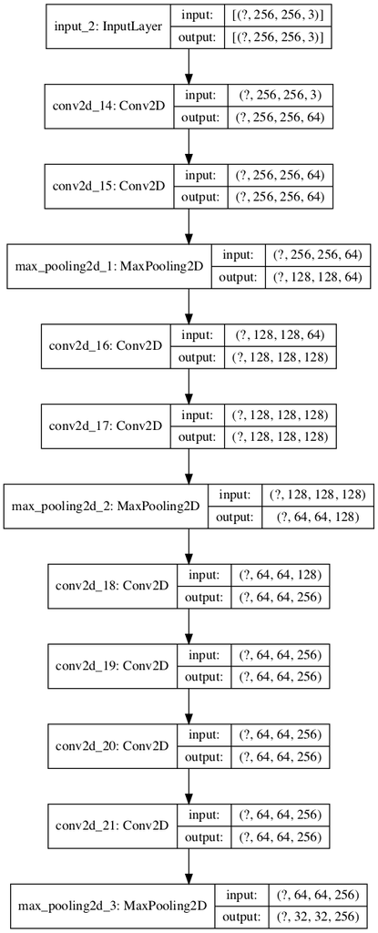

```python
# plot model architecture
plot_model(model, show_shapes=True)
```

## 4.2 How to Implement the Inception Module

The key innovation on the inception model is called the inception module. This is a block of parallel convolutional layers with different sized filters (e.g. 1 × 1, 3 × 3, 5 × 5) and a 3 × 3 max pooling layer, the results of which are then concatenated.

This is a very simple and powerful architectural unit that allows the model to learn not only parallel filters of the same size, but parallel filters of differing sizes, allowing learning at multiple scales.

```python
from tensorflow.keras.layers import concatenate

# function for creating a naive inception block
def naive_inception_module(layer_in, f1, f2, f3):
	# 1x1 conv
	conv1 = Conv2D(f1, (1,1), padding='same', activation='relu')(layer_in)
	# 3x3 conv
	conv3 = Conv2D(f2, (3,3), padding='same', activation='relu')(layer_in)
	# 5x5 conv
	conv5 = Conv2D(f3, (5,5), padding='same', activation='relu')(layer_in)
	# 3x3 max pooling
	pool = MaxPooling2D((3,3), strides=(1,1), padding='same')(layer_in)
	# concatenate filters, assumes filters/channels last
	layer_out = concatenate([conv1, conv3, conv5, pool], axis=-1)
	return layer_out

# define model input
visible = Input(shape=(256, 256, 3))
# add inception module
layer = naive_inception_module(visible, 64, 128, 32)
# create model
model = Model(inputs=visible, outputs=layer)
# summarize model
model.summary()
```

```
Model: "model_2"
__________________________________________________________________________________________________
Layer (type)                    Output Shape         Param #     Connected to
==================================================================================================
input_3 (InputLayer)            [(None, 256, 256, 3) 0
__________________________________________________________________________________________________
conv2d_22 (Conv2D)              (None, 256, 256, 64) 256         input_3[0][0]
__________________________________________________________________________________________________
conv2d_23 (Conv2D)              (None, 256, 256, 128 3584        input_3[0][0]
__________________________________________________________________________________________________
conv2d_24 (Conv2D)              (None, 256, 256, 32) 2432        input_3[0][0]
__________________________________________________________________________________________________
max_pooling2d_4 (MaxPooling2D)  (None, 256, 256, 3)  0           input_3[0][0]
__________________________________________________________________________________________________
concatenate (Concatenate)       (None, 256, 256, 227 0           conv2d_22[0][0]
                                                                 conv2d_23[0][0]
                                                                 conv2d_24[0][0]
                                                                 max_pooling2d_4[0][0]
==================================================================================================
Total params: 6,272
Trainable params: 6,272
Non-trainable params: 0
__________________________________________________________________________________________________
```

```python
64 + 128 + 32 + 3
```

```
227
```

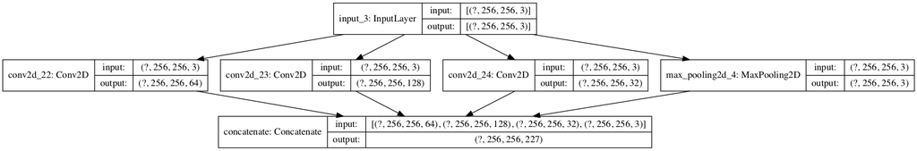

```python
# plot model architecture
plot_model(model, show_shapes=True)
```

The version of the inception module that we have implemented is called the **naive inception** module. A modification to the module was made in order to reduce the amount of computation required. Specifically, 1 × 1 convolutional layers were added to reduce the number of filters before the 3 × 3 and 5 × 5 convolutional layers, and to increase the number of filters after the pooling layer.

```python
# function for creating a projected inception module
def inception_module(layer_in, f1, f2_in, f2_out, f3_in, f3_out, f4_out):
	# 1x1 conv
	conv1 = Conv2D(f1, (1,1), padding='same', activation='relu')(layer_in)
	# 3x3 conv
	conv3 = Conv2D(f2_in, (1,1), padding='same', activation='relu')(layer_in)
	conv3 = Conv2D(f2_out, (3,3), padding='same', activation='relu')(conv3)
	# 5x5 conv
	conv5 = Conv2D(f3_in, (1,1), padding='same', activation='relu')(layer_in)
	conv5 = Conv2D(f3_out, (5,5), padding='same', activation='relu')(conv5)
	# 3x3 max pooling
	pool = MaxPooling2D((3,3), strides=(1,1), padding='same')(layer_in)
	pool = Conv2D(f4_out, (1,1), padding='same', activation='relu')(pool)
	# concatenate filters, assumes filters/channels last
	layer_out = concatenate([conv1, conv3, conv5, pool], axis=-1)
	return layer_out

# define model input
visible = Input(shape=(256, 256, 3))
# add inception block 1
layer = inception_module(visible, 64, 96, 128, 16, 32, 32)
# add inception block 1
layer = inception_module(layer, 128, 128, 192, 32, 96, 64)
# create model
model = Model(inputs=visible, outputs=layer)
# summarize model
model.summary()
```

```
Model: "model_3"
__________________________________________________________________________________________________
Layer (type)                    Output Shape         Param #     Connected to
==================================================================================================
input_4 (InputLayer)            [(None, 256, 256, 3) 0
__________________________________________________________________________________________________
conv2d_26 (Conv2D)              (None, 256, 256, 96) 384         input_4[0][0]
__________________________________________________________________________________________________
conv2d_28 (Conv2D)              (None, 256, 256, 16) 64          input_4[0][0]
__________________________________________________________________________________________________
max_pooling2d_5 (MaxPooling2D)  (None, 256, 256, 3)  0           input_4[0][0]
__________________________________________________________________________________________________
conv2d_25 (Conv2D)              (None, 256, 256, 64) 256         input_4[0][0]
__________________________________________________________________________________________________
conv2d_27 (Conv2D)              (None, 256, 256, 128 110720      conv2d_26[0][0]
__________________________________________________________________________________________________
conv2d_29 (Conv2D)              (None, 256, 256, 32) 12832       conv2d_28[0][0]
__________________________________________________________________________________________________
conv2d_30 (Conv2D)              (None, 256, 256, 32) 128         max_pooling2d_5[0][0]
__________________________________________________________________________________________________
concatenate_1 (Concatenate)     (None, 256, 256, 256 0           conv2d_25[0][0]
                                                                 conv2d_27[0][0]
                                                                 conv2d_29[0][0]
                                                                 conv2d_30[0][0]
__________________________________________________________________________________________________
conv2d_32 (Conv2D)              (None, 256, 256, 128 32896       concatenate_1[0][0]
__________________________________________________________________________________________________
conv2d_34 (Conv2D)              (None, 256, 256, 32) 8224        concatenate_1[0][0]
__________________________________________________________________________________________________
max_pooling2d_6 (MaxPooling2D)  (None, 256, 256, 256 0           concatenate_1[0][0]
__________________________________________________________________________________________________
conv2d_31 (Conv2D)              (None, 256, 256, 128 32896       concatenate_1[0][0]
__________________________________________________________________________________________________
conv2d_33 (Conv2D)              (None, 256, 256, 192 221376      conv2d_32[0][0]
__________________________________________________________________________________________________
conv2d_35 (Conv2D)              (None, 256, 256, 96) 76896       conv2d_34[0][0]
__________________________________________________________________________________________________
conv2d_36 (Conv2D)              (None, 256, 256, 64) 16448       max_pooling2d_6[0][0]
__________________________________________________________________________________________________
concatenate_2 (Concatenate)     (None, 256, 256, 480 0           conv2d_31[0][0]
                                                                 conv2d_33[0][0]
                                                                 conv2d_35[0][0]
                                                                 conv2d_36[0][0]
==================================================================================================
Total params: 513,120
Trainable params: 513,120
Non-trainable params: 0
__________________________________________________________________________________________________
```

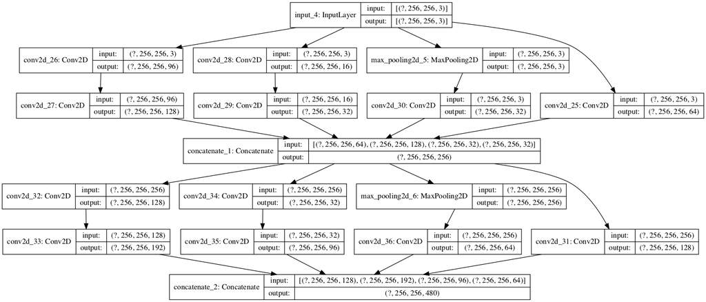

```python
# plot model architecture
plot_model(model, show_shapes=True)
```

## 4.3 How to Implement the Residual Module

The residual module, specifically the identity residual model, is a block of two convolutional layers with the same number of filters and a small filter size where the output of the second layer is added with the input to the first convolutional layer.

A limitation with this direct implementation is that if the number of filters in the input layer does not match the number of filters in the last convolutional layer of the module (defined by `n_filters`), then we will get an error. One solution is to use a 1 × 1 convolution layer, often referred to as a projection layer, to either increase the number of filters for the input layer or reduce the number of filters for the last convolutional layer in the module.

```python
from tensorflow.keras.layers import add
from tensorflow.keras.layers import Activation

# function for creating an identity or projection residual module
def residual_module(layer_in, n_filters):
	merge_input = layer_in
	# check if the number of filters needs to be increase, assumes channels last format
	if layer_in.shape[-1] != n_filters:
		merge_input = Conv2D(n_filters, (1,1), padding='same', activation='relu', kernel_initializer='he_normal')(layer_in)
	# conv1
	conv1 = Conv2D(n_filters, (3,3), padding='same', activation='relu', kernel_initializer='he_normal')(layer_in)
	# conv2
	conv2 = Conv2D(n_filters, (3,3), padding='same', activation='linear', kernel_initializer='he_normal')(conv1)
	# add filters, assumes filters/channels last
	layer_out = add([conv2, merge_input])
	# activation function
	layer_out = Activation('relu')(layer_out)
	return layer_out

# define model input
visible = Input(shape=(256, 256, 3))
# add vgg module
layer = residual_module(visible, 64)
# create model
model = Model(inputs=visible, outputs=layer)
# summarize model
model.summary()
```

```
Model: "model_4"
__________________________________________________________________________________________________
Layer (type)                    Output Shape         Param #     Connected to
==================================================================================================
input_5 (InputLayer)            [(None, 256, 256, 3) 0
__________________________________________________________________________________________________
conv2d_38 (Conv2D)              (None, 256, 256, 64) 1792        input_5[0][0]
__________________________________________________________________________________________________
conv2d_39 (Conv2D)              (None, 256, 256, 64) 36928       conv2d_38[0][0]
__________________________________________________________________________________________________
conv2d_37 (Conv2D)              (None, 256, 256, 64) 256         input_5[0][0]
__________________________________________________________________________________________________
add (Add)                       (None, 256, 256, 64) 0           conv2d_39[0][0]
                                                                 conv2d_37[0][0]
__________________________________________________________________________________________________
activation (Activation)         (None, 256, 256, 64) 0           add[0][0]
==================================================================================================
Total params: 38,976
Trainable params: 38,976
Non-trainable params: 0
__________________________________________________________________________________________________
```

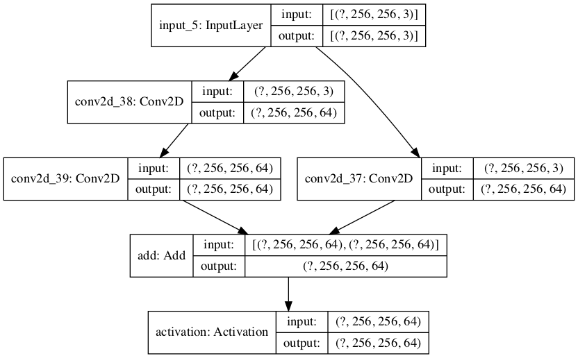

```python
# plot model architecture
plot_model(model, show_shapes=True)
```

```python
! ls ~/.keras/models/
```

```
densenet121_weights_tf_dim_ordering_tf_kernels.h5
imagenet_class_index.json
inception_v3_weights_tf_dim_ordering_tf_kernels.h5
resnet50_weights_tf_dim_ordering_tf_kernels.h5
resnet50_weights_tf_dim_ordering_tf_kernels_notop.h5
vgg16_weights_tf_dim_ordering_tf_kernels.h5
vgg16_weights_tf_dim_ordering_tf_kernels_notop.h5
xception_weights_tf_dim_ordering_tf_kernels.h5
```

# 5 How to Use Pre-Trained Models and Transfer Learning

详情参考[API](https://keras.io/api/applications/)。

Deep convolutional neural network models may take days or even weeks to train on very large datasets. A way to short-cut this process is to re-use the model weights from pre-trained models that were developed for standard computer vision benchmark datasets, such as the ImageNet image recognition tasks.

## 5.1 What Is Transfer Learning?

Transfer learning generally refers to a process where a model trained on one problem is used in some way on a second, related problem. In deep learning, transfer learning is a technique whereby a neural network model is first trained on a problem similar to the problem that is being solved. One or more layers from the trained model are then used in a new model trained on the problem of interest.

The weights in re-used layers may be used as the starting point for the training process and adapted in response to the new problem.

## 5.2 Transfer Learning for Image Recognition

This is desirable for a number of reasons, not least:

- **Useful Learned Features**: The models have learned how to detect generic features from photographs, given that they were trained on more than 1,000,000 images for 1,000 categories.
- **State-of-the-Art Performance**: The models achieved state-of-the-art performance and remain effective on the specific image recognition task for which they were developed.
- **Easily Accessible**: The model weights are provided as free downloadable files and many libraries provide convenient APIs to download and use the models directly.

The model weights can be downloaded and used in the same model architecture using a range of different deep learning libraries, including Keras.

## 5.3 How to Use Pre-Trained Models

- **Classifier**: The pre-trained model is used directly to classify new images.
- **Standalone Feature Extractor**: The pre-trained model, or some portion of the model, is used to pre-process images and extract relevant features.
- **Integrated Feature Extractor**: The pre-trained model, or some portion of the model, is integrated into a new model, but layers of the pre-trained model are frozen during training.
- **Weight Initialization**: The pre-trained model, or some portion of the model, is integrated into a new model, and the layers of the pre-trained model are trained in concert with the new model

## 5.4 Models for Transfer Learning

Perhaps three of the more popular models are as follows:

- **VGG** (e.g. VGG16 or VGG19).
- **GoogLeNet** (e.g. InceptionV3).
- **Residual Network** (e.g. ResNet50).

The first time a pre-trained model is loaded, Keras will download the required model weights, which may take some time given the speed of your internet connection. Weights are stored in the `.keras/models/` directory under your home directory and will be loaded from this location the next time that they are used. When loading a given model, the `include_top` argument can be set to False, in which case the fully-connected output layers of the model used to make predictions is not loaded, allowing a new output layer to be added and trained.

Additionally, when the `include_top` argument is False, the `input_tensor` argument must be specified, allowing the expected fixed-sized input of the model to be changed.

A model without a top will output activations from the last convolutional or pooling layer directly.

```python
# example of loading the vgg16 model
from tensorflow.keras.applications.vgg16 import VGG16
# load model
model = VGG16()
# summarize the model
model.summary()
```

```
Model: "vgg16"
_________________________________________________________________
Layer (type)                 Output Shape              Param #
=================================================================
input_6 (InputLayer)         [(None, 224, 224, 3)]     0
_________________________________________________________________
block1_conv1 (Conv2D)        (None, 224, 224, 64)      1792
_________________________________________________________________
block1_conv2 (Conv2D)        (None, 224, 224, 64)      36928
_________________________________________________________________
block1_pool (MaxPooling2D)   (None, 112, 112, 64)      0
_________________________________________________________________
block2_conv1 (Conv2D)        (None, 112, 112, 128)     73856
_________________________________________________________________
block2_conv2 (Conv2D)        (None, 112, 112, 128)     147584
_________________________________________________________________
block2_pool (MaxPooling2D)   (None, 56, 56, 128)       0
_________________________________________________________________
block3_conv1 (Conv2D)        (None, 56, 56, 256)       295168
_________________________________________________________________
block3_conv2 (Conv2D)        (None, 56, 56, 256)       590080
_________________________________________________________________
block3_conv3 (Conv2D)        (None, 56, 56, 256)       590080
_________________________________________________________________
block3_pool (MaxPooling2D)   (None, 28, 28, 256)       0
_________________________________________________________________
block4_conv1 (Conv2D)        (None, 28, 28, 512)       1180160
_________________________________________________________________
block4_conv2 (Conv2D)        (None, 28, 28, 512)       2359808
_________________________________________________________________
block4_conv3 (Conv2D)        (None, 28, 28, 512)       2359808
_________________________________________________________________
block4_pool (MaxPooling2D)   (None, 14, 14, 512)       0
_________________________________________________________________
block5_conv1 (Conv2D)        (None, 14, 14, 512)       2359808
_________________________________________________________________
block5_conv2 (Conv2D)        (None, 14, 14, 512)       2359808
_________________________________________________________________
block5_conv3 (Conv2D)        (None, 14, 14, 512)       2359808
_________________________________________________________________
block5_pool (MaxPooling2D)   (None, 7, 7, 512)         0
_________________________________________________________________
flatten (Flatten)            (None, 25088)             0
_________________________________________________________________
fc1 (Dense)                  (None, 4096)              102764544
_________________________________________________________________
fc2 (Dense)                  (None, 4096)              16781312
_________________________________________________________________
predictions (Dense)          (None, 1000)              4097000
=================================================================
Total params: 138,357,544
Trainable params: 138,357,544
Non-trainable params: 0
_________________________________________________________________
```

```python
# load model
new_input = Input(shape=(640, 480, 3))
model = VGG16(include_top=False, input_tensor=new_input)
# summarize the model
model.summary()
```

```
Model: "vgg16"
_________________________________________________________________
Layer (type)                 Output Shape              Param #
=================================================================
input_7 (InputLayer)         [(None, 640, 480, 3)]     0
_________________________________________________________________
block1_conv1 (Conv2D)        (None, 640, 480, 64)      1792
_________________________________________________________________
block1_conv2 (Conv2D)        (None, 640, 480, 64)      36928
_________________________________________________________________
block1_pool (MaxPooling2D)   (None, 320, 240, 64)      0
_________________________________________________________________
block2_conv1 (Conv2D)        (None, 320, 240, 128)     73856
_________________________________________________________________
block2_conv2 (Conv2D)        (None, 320, 240, 128)     147584
_________________________________________________________________
block2_pool (MaxPooling2D)   (None, 160, 120, 128)     0
_________________________________________________________________
block3_conv1 (Conv2D)        (None, 160, 120, 256)     295168
_________________________________________________________________
block3_conv2 (Conv2D)        (None, 160, 120, 256)     590080
_________________________________________________________________
block3_conv3 (Conv2D)        (None, 160, 120, 256)     590080
_________________________________________________________________
block3_pool (MaxPooling2D)   (None, 80, 60, 256)       0
_________________________________________________________________
block4_conv1 (Conv2D)        (None, 80, 60, 512)       1180160
_________________________________________________________________
block4_conv2 (Conv2D)        (None, 80, 60, 512)       2359808
_________________________________________________________________
block4_conv3 (Conv2D)        (None, 80, 60, 512)       2359808
_________________________________________________________________
block4_pool (MaxPooling2D)   (None, 40, 30, 512)       0
_________________________________________________________________
block5_conv1 (Conv2D)        (None, 40, 30, 512)       2359808
_________________________________________________________________
block5_conv2 (Conv2D)        (None, 40, 30, 512)       2359808
_________________________________________________________________
block5_conv3 (Conv2D)        (None, 40, 30, 512)       2359808
_________________________________________________________________
block5_pool (MaxPooling2D)   (None, 20, 15, 512)       0
=================================================================
Total params: 14,714,688
Trainable params: 14,714,688
Non-trainable params: 0
_________________________________________________________________
```

One approach to summarizing these activations for their use in a classifier or as a feature vector representation of input is to add a **global pooling layer**, such as a max global pooling or average global pooling. The result is a vector that can be used as a feature descriptor for an input (e.g. a vector of extracted features). Keras provides this capability directly via the pooling argument that can be set to `avg` or max`.

```python
# load model
new_input = Input(shape=(640, 480, 3))
model = VGG16(include_top=False, input_tensor=new_input, pooling="max")
# summarize the model
model.summary()
```

```
Model: "vgg16"
_________________________________________________________________
Layer (type)                 Output Shape              Param #
=================================================================
input_8 (InputLayer)         [(None, 640, 480, 3)]     0
_________________________________________________________________
block1_conv1 (Conv2D)        (None, 640, 480, 64)      1792
_________________________________________________________________
block1_conv2 (Conv2D)        (None, 640, 480, 64)      36928
_________________________________________________________________
block1_pool (MaxPooling2D)   (None, 320, 240, 64)      0
_________________________________________________________________
block2_conv1 (Conv2D)        (None, 320, 240, 128)     73856
_________________________________________________________________
block2_conv2 (Conv2D)        (None, 320, 240, 128)     147584
_________________________________________________________________
block2_pool (MaxPooling2D)   (None, 160, 120, 128)     0
_________________________________________________________________
block3_conv1 (Conv2D)        (None, 160, 120, 256)     295168
_________________________________________________________________
block3_conv2 (Conv2D)        (None, 160, 120, 256)     590080
_________________________________________________________________
block3_conv3 (Conv2D)        (None, 160, 120, 256)     590080
_________________________________________________________________
block3_pool (MaxPooling2D)   (None, 80, 60, 256)       0
_________________________________________________________________
block4_conv1 (Conv2D)        (None, 80, 60, 512)       1180160
_________________________________________________________________
block4_conv2 (Conv2D)        (None, 80, 60, 512)       2359808
_________________________________________________________________
block4_conv3 (Conv2D)        (None, 80, 60, 512)       2359808
_________________________________________________________________
block4_pool (MaxPooling2D)   (None, 40, 30, 512)       0
_________________________________________________________________
block5_conv1 (Conv2D)        (None, 40, 30, 512)       2359808
_________________________________________________________________
block5_conv2 (Conv2D)        (None, 40, 30, 512)       2359808
_________________________________________________________________
block5_conv3 (Conv2D)        (None, 40, 30, 512)       2359808
_________________________________________________________________
block5_pool (MaxPooling2D)   (None, 20, 15, 512)       0
_________________________________________________________________
global_max_pooling2d (Global (None, 512)               0
=================================================================
Total params: 14,714,688
Trainable params: 14,714,688
Non-trainable params: 0
_________________________________________________________________
```

Images can be prepared for a given model using the `preprocess_input()` function; e.g., pixel scaling is performed in a way that was performed to images in the training dataset when the model was developed.

```python
# prepare an image
from tensorflow.keras.applications.vgg16 import preprocess_input
# images = ...
# prepared_images = preprocess_input(images)
```

Finally, you may wish to use a model architecture on your dataset, but not use the pre-trained weights, and instead initialize the model with random weights and train the model from scratch. This can be achieved by setting the **weights** argument to None instead of the default `imagenet`. Additionally, the `classes` argument can be set to define the number of classes in your dataset, which will then be configured for you in the output layer of the model.

```python
# define a new model with random weights and 10 classes
new_input = Input(shape=(640, 480, 3))
model = VGG16(weights=None, input_tensor=new_input, classes=10)
model.summary()
```

```
Model: "vgg16"
_________________________________________________________________
Layer (type)                 Output Shape              Param #
=================================================================
input_9 (InputLayer)         [(None, 640, 480, 3)]     0
_________________________________________________________________
block1_conv1 (Conv2D)        (None, 640, 480, 64)      1792
_________________________________________________________________
block1_conv2 (Conv2D)        (None, 640, 480, 64)      36928
_________________________________________________________________
block1_pool (MaxPooling2D)   (None, 320, 240, 64)      0
_________________________________________________________________
block2_conv1 (Conv2D)        (None, 320, 240, 128)     73856
_________________________________________________________________
block2_conv2 (Conv2D)        (None, 320, 240, 128)     147584
_________________________________________________________________
block2_pool (MaxPooling2D)   (None, 160, 120, 128)     0
_________________________________________________________________
block3_conv1 (Conv2D)        (None, 160, 120, 256)     295168
_________________________________________________________________
block3_conv2 (Conv2D)        (None, 160, 120, 256)     590080
_________________________________________________________________
block3_conv3 (Conv2D)        (None, 160, 120, 256)     590080
_________________________________________________________________
block3_pool (MaxPooling2D)   (None, 80, 60, 256)       0
_________________________________________________________________
block4_conv1 (Conv2D)        (None, 80, 60, 512)       1180160
_________________________________________________________________
block4_conv2 (Conv2D)        (None, 80, 60, 512)       2359808
_________________________________________________________________
block4_conv3 (Conv2D)        (None, 80, 60, 512)       2359808
_________________________________________________________________
block4_pool (MaxPooling2D)   (None, 40, 30, 512)       0
_________________________________________________________________
block5_conv1 (Conv2D)        (None, 40, 30, 512)       2359808
_________________________________________________________________
block5_conv2 (Conv2D)        (None, 40, 30, 512)       2359808
_________________________________________________________________
block5_conv3 (Conv2D)        (None, 40, 30, 512)       2359808
_________________________________________________________________
block5_pool (MaxPooling2D)   (None, 20, 15, 512)       0
_________________________________________________________________
flatten (Flatten)            (None, 153600)            0
_________________________________________________________________
fc1 (Dense)                  (None, 4096)              629149696
_________________________________________________________________
fc2 (Dense)                  (None, 4096)              16781312
_________________________________________________________________
predictions (Dense)          (None, 10)                40970
=================================================================
Total params: 660,686,666
Trainable params: 660,686,666
Non-trainable params: 0
_________________________________________________________________
```

## 5.5 Examples of Using Pre-Trained Models

### 5.5.1 Pre-Trained Model as Classifier

First, the photograph needs to loaded and reshaped to a 224 × 224 square, expected by the model, and the pixel values scaled in the way expected by the model.

```python
# example of using a pre-trained model as a classifier
from tensorflow.keras.preprocessing.image import load_img
from tensorflow.keras.preprocessing.image import img_to_array
from tensorflow.keras.applications.vgg16 import preprocess_input
from tensorflow.keras.applications.vgg16 import decode_predictions
from tensorflow.keras.applications.vgg16 import VGG16
from matplotlib import pyplot as plt

# load an image from file
image = load_img('dog.jpg', target_size=(224, 224))
# convert the image pixels to a numpy array
image = img_to_array(image)
image.shape
```

```
(224, 224, 3)
```

```python
# reshape data for the model
image = image.reshape((1, image.shape[0], image.shape[1], image.shape[2]))
image.shape
```

```
(1, 224, 224, 3)
```

```python
# prepare the image for the VGG model
image = preprocess_input(image)
# load the model
model = VGG16()
# predict the probability across all output classes
yhat = model.predict(image)
# convert the probabilities to class labels
label = decode_predictions(yhat)
# retrieve the most likely result, e.g. highest probability
label
```

```
[[('n02107142', 'Doberman', 0.3359488),
  ('n02105412', 'kelpie', 0.21615875),
  ('n02106550', 'Rottweiler', 0.17698683),
  ('n02089078', 'black-and-tan_coonhound', 0.12776826),
  ('n02107312', 'miniature_pinscher', 0.037303723)]]
```

```python
yhat.shape
```

```
(1, 1000)
```

### 5.5.2 Pre-Trained Model as Feature Extractor Preprocessor

```python
from tensorflow.keras.models import Model
from pickle import dump

# load an image from file
image = load_img('dog.jpg', target_size=(224, 224))
# convert the image pixels to a numpy array
image = img_to_array(image)
# reshape data for the model
image = image.reshape((1, image.shape[0], image.shape[1], image.shape[2]))
# prepare the image for the VGG model
image = preprocess_input(image)
# load model
model = VGG16()
# remove the output layer
model = Model(inputs=model.inputs, outputs=model.layers[-2].output)
# get extracted features
features = model.predict(image)
print(features.shape)
```

```
(1, 4096)
```

```python
model.summary()
```

```
Model: "model_5"
_________________________________________________________________
Layer (type)                 Output Shape              Param #
=================================================================
input_11 (InputLayer)        [(None, 224, 224, 3)]     0
_________________________________________________________________
block1_conv1 (Conv2D)        (None, 224, 224, 64)      1792
_________________________________________________________________
block1_conv2 (Conv2D)        (None, 224, 224, 64)      36928
_________________________________________________________________
block1_pool (MaxPooling2D)   (None, 112, 112, 64)      0
_________________________________________________________________
block2_conv1 (Conv2D)        (None, 112, 112, 128)     73856
_________________________________________________________________
block2_conv2 (Conv2D)        (None, 112, 112, 128)     147584
_________________________________________________________________
block2_pool (MaxPooling2D)   (None, 56, 56, 128)       0
_________________________________________________________________
block3_conv1 (Conv2D)        (None, 56, 56, 256)       295168
_________________________________________________________________
block3_conv2 (Conv2D)        (None, 56, 56, 256)       590080
_________________________________________________________________
block3_conv3 (Conv2D)        (None, 56, 56, 256)       590080
_________________________________________________________________
block3_pool (MaxPooling2D)   (None, 28, 28, 256)       0
_________________________________________________________________
block4_conv1 (Conv2D)        (None, 28, 28, 512)       1180160
_________________________________________________________________
block4_conv2 (Conv2D)        (None, 28, 28, 512)       2359808
_________________________________________________________________
block4_conv3 (Conv2D)        (None, 28, 28, 512)       2359808
_________________________________________________________________
block4_pool (MaxPooling2D)   (None, 14, 14, 512)       0
_________________________________________________________________
block5_conv1 (Conv2D)        (None, 14, 14, 512)       2359808
_________________________________________________________________
block5_conv2 (Conv2D)        (None, 14, 14, 512)       2359808
_________________________________________________________________
block5_conv3 (Conv2D)        (None, 14, 14, 512)       2359808
_________________________________________________________________
block5_pool (MaxPooling2D)   (None, 7, 7, 512)         0
_________________________________________________________________
flatten (Flatten)            (None, 25088)             0
_________________________________________________________________
fc1 (Dense)                  (None, 4096)              102764544
_________________________________________________________________
fc2 (Dense)                  (None, 4096)              16781312
=================================================================
Total params: 134,260,544
Trainable params: 134,260,544
Non-trainable params: 0
_________________________________________________________________
```

```python
VGG16().inputs
```

```
[<tf.Tensor 'input_12:0' shape=(None, 224, 224, 3) dtype=float32>]
```

```python
len(VGG16().layers)
```

```
23
```

```python
model.layers[-2].output
```

```
<tf.Tensor 'fc1_3/Identity:0' shape=(None, 4096) dtype=float32>
```

也可以使用`get_layer()`方法，请参考API。

```python
# save to file
dump(features, open('dog.pkl', 'wb'))
```

### 5.5.3 Pre-Trained Model as Feature Extractor in Model

We can use some or all of the layers in a pre-trained model as a feature extraction component of a new model directly. This can be achieved by loading the model, then simply adding new layers.

The weights of the VGG16 model and the weights for the new model will all be trained together on the new dataset.

```python
# example of tending the vgg16 model
from tensorflow.keras.layers import Dense
from tensorflow.keras.layers import Flatten

# load model without classifier layers
model = VGG16(include_top=False, input_shape=(300, 300, 3))
# add new classifier layers
flat1 = Flatten()(model.layers[-1].output)
class1 = Dense(1024, activation='relu')(flat1)
output = Dense(10, activation='softmax')(class1)
# define new model
model = Model(inputs=model.inputs, outputs=output)
# summarize
model.summary()
```

```
Model: "model_6"
_________________________________________________________________
Layer (type)                 Output Shape              Param #
=================================================================
input_14 (InputLayer)        [(None, 300, 300, 3)]     0
_________________________________________________________________
block1_conv1 (Conv2D)        (None, 300, 300, 64)      1792
_________________________________________________________________
block1_conv2 (Conv2D)        (None, 300, 300, 64)      36928
_________________________________________________________________
block1_pool (MaxPooling2D)   (None, 150, 150, 64)      0
_________________________________________________________________
block2_conv1 (Conv2D)        (None, 150, 150, 128)     73856
_________________________________________________________________
block2_conv2 (Conv2D)        (None, 150, 150, 128)     147584
_________________________________________________________________
block2_pool (MaxPooling2D)   (None, 75, 75, 128)       0
_________________________________________________________________
block3_conv1 (Conv2D)        (None, 75, 75, 256)       295168
_________________________________________________________________
block3_conv2 (Conv2D)        (None, 75, 75, 256)       590080
_________________________________________________________________
block3_conv3 (Conv2D)        (None, 75, 75, 256)       590080
_________________________________________________________________
block3_pool (MaxPooling2D)   (None, 37, 37, 256)       0
_________________________________________________________________
block4_conv1 (Conv2D)        (None, 37, 37, 512)       1180160
_________________________________________________________________
block4_conv2 (Conv2D)        (None, 37, 37, 512)       2359808
_________________________________________________________________
block4_conv3 (Conv2D)        (None, 37, 37, 512)       2359808
_________________________________________________________________
block4_pool (MaxPooling2D)   (None, 18, 18, 512)       0
_________________________________________________________________
block5_conv1 (Conv2D)        (None, 18, 18, 512)       2359808
_________________________________________________________________
block5_conv2 (Conv2D)        (None, 18, 18, 512)       2359808
_________________________________________________________________
block5_conv3 (Conv2D)        (None, 18, 18, 512)       2359808
_________________________________________________________________
block5_pool (MaxPooling2D)   (None, 9, 9, 512)         0
_________________________________________________________________
flatten (Flatten)            (None, 41472)             0
_________________________________________________________________
dense (Dense)                (None, 1024)              42468352
_________________________________________________________________
dense_1 (Dense)              (None, 10)                10250
=================================================================
Total params: 57,193,290
Trainable params: 57,193,290
Non-trainable params: 0
_________________________________________________________________
```

```python
VGG16(include_top=False, input_shape=(300, 300, 3)).summary()
```

```
Model: "vgg16"
_________________________________________________________________
Layer (type)                 Output Shape              Param #
=================================================================
input_15 (InputLayer)        [(None, 300, 300, 3)]     0
_________________________________________________________________
block1_conv1 (Conv2D)        (None, 300, 300, 64)      1792
_________________________________________________________________
block1_conv2 (Conv2D)        (None, 300, 300, 64)      36928
_________________________________________________________________
block1_pool (MaxPooling2D)   (None, 150, 150, 64)      0
_________________________________________________________________
block2_conv1 (Conv2D)        (None, 150, 150, 128)     73856
_________________________________________________________________
block2_conv2 (Conv2D)        (None, 150, 150, 128)     147584
_________________________________________________________________
block2_pool (MaxPooling2D)   (None, 75, 75, 128)       0
_________________________________________________________________
block3_conv1 (Conv2D)        (None, 75, 75, 256)       295168
_________________________________________________________________
block3_conv2 (Conv2D)        (None, 75, 75, 256)       590080
_________________________________________________________________
block3_conv3 (Conv2D)        (None, 75, 75, 256)       590080
_________________________________________________________________
block3_pool (MaxPooling2D)   (None, 37, 37, 256)       0
_________________________________________________________________
block4_conv1 (Conv2D)        (None, 37, 37, 512)       1180160
_________________________________________________________________
block4_conv2 (Conv2D)        (None, 37, 37, 512)       2359808
_________________________________________________________________
block4_conv3 (Conv2D)        (None, 37, 37, 512)       2359808
_________________________________________________________________
block4_pool (MaxPooling2D)   (None, 18, 18, 512)       0
_________________________________________________________________
block5_conv1 (Conv2D)        (None, 18, 18, 512)       2359808
_________________________________________________________________
block5_conv2 (Conv2D)        (None, 18, 18, 512)       2359808
_________________________________________________________________
block5_conv3 (Conv2D)        (None, 18, 18, 512)       2359808
_________________________________________________________________
block5_pool (MaxPooling2D)   (None, 9, 9, 512)         0
=================================================================
Total params: 14,714,688
Trainable params: 14,714,688
Non-trainable params: 0
_________________________________________________________________
```

Alternately, we may wish to use the VGG16 model layers, but train the new layers of the model without updating the weights of the VGG16 layers.

This can be achieved by setting the trainable property on each of the layers in the loaded VGG model to `False` prior to training.

```python
# load model without classifier layers
model = VGG16(include_top=False, input_shape=(300, 300, 3))
# mark loaded layers as not trainable
for layer in model.layers:
    layer.trainable = False
model.summary()
```

```
Model: "vgg16"
_________________________________________________________________
Layer (type)                 Output Shape              Param #
=================================================================
input_16 (InputLayer)        [(None, 300, 300, 3)]     0
_________________________________________________________________
block1_conv1 (Conv2D)        (None, 300, 300, 64)      1792
_________________________________________________________________
block1_conv2 (Conv2D)        (None, 300, 300, 64)      36928
_________________________________________________________________
block1_pool (MaxPooling2D)   (None, 150, 150, 64)      0
_________________________________________________________________
block2_conv1 (Conv2D)        (None, 150, 150, 128)     73856
_________________________________________________________________
block2_conv2 (Conv2D)        (None, 150, 150, 128)     147584
_________________________________________________________________
block2_pool (MaxPooling2D)   (None, 75, 75, 128)       0
_________________________________________________________________
block3_conv1 (Conv2D)        (None, 75, 75, 256)       295168
_________________________________________________________________
block3_conv2 (Conv2D)        (None, 75, 75, 256)       590080
_________________________________________________________________
block3_conv3 (Conv2D)        (None, 75, 75, 256)       590080
_________________________________________________________________
block3_pool (MaxPooling2D)   (None, 37, 37, 256)       0
_________________________________________________________________
block4_conv1 (Conv2D)        (None, 37, 37, 512)       1180160
_________________________________________________________________
block4_conv2 (Conv2D)        (None, 37, 37, 512)       2359808
_________________________________________________________________
block4_conv3 (Conv2D)        (None, 37, 37, 512)       2359808
_________________________________________________________________
block4_pool (MaxPooling2D)   (None, 18, 18, 512)       0
_________________________________________________________________
block5_conv1 (Conv2D)        (None, 18, 18, 512)       2359808
_________________________________________________________________
block5_conv2 (Conv2D)        (None, 18, 18, 512)       2359808
_________________________________________________________________
block5_conv3 (Conv2D)        (None, 18, 18, 512)       2359808
_________________________________________________________________
block5_pool (MaxPooling2D)   (None, 9, 9, 512)         0
=================================================================
Total params: 14,714,688
Trainable params: 0
Non-trainable params: 14,714,688
_________________________________________________________________
```

You can pick and choose which layers are trainable. For example, perhaps you want to retrain some of the convolutional layers deep in the model, but none of the layers earlier in the model.

```python
# load model without classifier layers
model = VGG16(include_top=False, input_shape=(300, 300, 3))
# mark some layers as not trainable
model.get_layer('block1_conv1').trainable = False
model.get_layer('block1_conv2').trainable = False
model.get_layer('block2_conv1').trainable = False
model.get_layer('block2_conv2').trainable = False
# add new classifier layers
flat1 = Flatten()(model.layers[-1].output)
class1 = Dense(1024, activation='relu')(flat1)
output = Dense(10, activation='softmax')(class1)
# define new model
model = Model(inputs=model.inputs, outputs=output)
# summarize
model.summary()
```

```
Model: "model_7"
_________________________________________________________________
Layer (type)                 Output Shape              Param #
=================================================================
input_17 (InputLayer)        [(None, 300, 300, 3)]     0
_________________________________________________________________
block1_conv1 (Conv2D)        (None, 300, 300, 64)      1792
_________________________________________________________________
block1_conv2 (Conv2D)        (None, 300, 300, 64)      36928
_________________________________________________________________
block1_pool (MaxPooling2D)   (None, 150, 150, 64)      0
_________________________________________________________________
block2_conv1 (Conv2D)        (None, 150, 150, 128)     73856
_________________________________________________________________
block2_conv2 (Conv2D)        (None, 150, 150, 128)     147584
_________________________________________________________________
block2_pool (MaxPooling2D)   (None, 75, 75, 128)       0
_________________________________________________________________
block3_conv1 (Conv2D)        (None, 75, 75, 256)       295168
_________________________________________________________________
block3_conv2 (Conv2D)        (None, 75, 75, 256)       590080
_________________________________________________________________
block3_conv3 (Conv2D)        (None, 75, 75, 256)       590080
_________________________________________________________________
block3_pool (MaxPooling2D)   (None, 37, 37, 256)       0
_________________________________________________________________
block4_conv1 (Conv2D)        (None, 37, 37, 512)       1180160
_________________________________________________________________
block4_conv2 (Conv2D)        (None, 37, 37, 512)       2359808
_________________________________________________________________
block4_conv3 (Conv2D)        (None, 37, 37, 512)       2359808
_________________________________________________________________
block4_pool (MaxPooling2D)   (None, 18, 18, 512)       0
_________________________________________________________________
block5_conv1 (Conv2D)        (None, 18, 18, 512)       2359808
_________________________________________________________________
block5_conv2 (Conv2D)        (None, 18, 18, 512)       2359808
_________________________________________________________________
block5_conv3 (Conv2D)        (None, 18, 18, 512)       2359808
_________________________________________________________________
block5_pool (MaxPooling2D)   (None, 9, 9, 512)         0
_________________________________________________________________
flatten_1 (Flatten)          (None, 41472)             0
_________________________________________________________________
dense_2 (Dense)              (None, 1024)              42468352
_________________________________________________________________
dense_3 (Dense)              (None, 10)                10250
=================================================================
Total params: 57,193,290
Trainable params: 56,933,130
Non-trainable params: 260,160
_________________________________________________________________
```